# Tarea I

Pablo Barranco 151528 , Paul Virueña 155265

8/2/2020

## Linear discriminant analysis

Para realizar el ejercicio correspondiente, primero cargamos los datos que ya contiene R, llamada *iris*.

```r
library(ggplot2)
data("iris")
str(iris)
```

```
## 'data.frame':    150 obs. of  5 variables:
##  $ Sepal.Length: num  5.1 4.9 4.7 4.6 5 5.4 4.6 5 4.4 4.9 ...
##  $ Sepal.Width : num  3.5 3 3.2 3.1 3.6 3.9 3.4 3.4 2.9 3.1 ...
##  $ Petal.Length: num  1.4 1.4 1.3 1.5 1.4 1.7 1.4 1.5 1.4 1.5 ...
##  $ Petal.Width : num  0.2 0.2 0.2 0.2 0.2 0.4 0.3 0.2 0.2 0.1 ...
##  $ Species     : Factor w/ 3 levels "setosa","versicolor",..: 1 1 1 1 1 1 1 1 1 1 ...
```

Podemos ver que los datos correspondientes, son 150 observaciones de tres especies flores, en donde se muestra las mediciones en centimetros del ancho y altura del sepalo (pieza floral que forma el cáliz de una flor) y de sus petalos.

```r
table(iris$Species)
```

```
##
##     setosa versicolor  virginica
##         50         50         50
```

De lo anterior podemos ver que para cada especie, tenemos 50 obvservaciones.

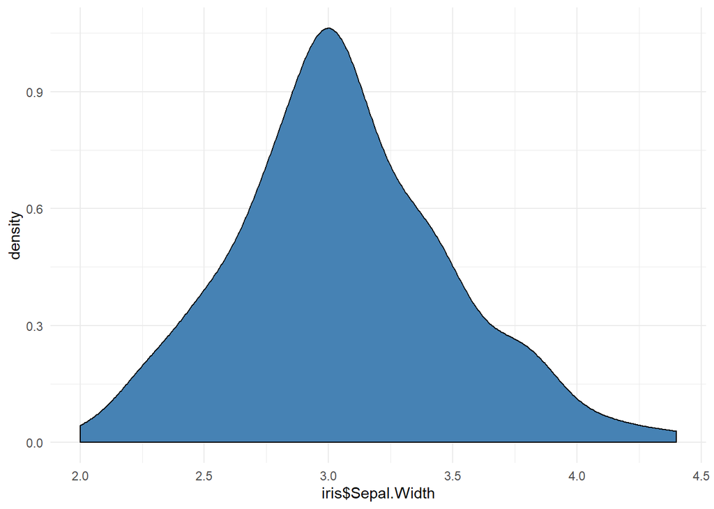

```r
(densid <- ggplot(iris)+geom_density(aes(x = iris$Sepal.Width), fill = 'steelblue')+theme_minimal())
```

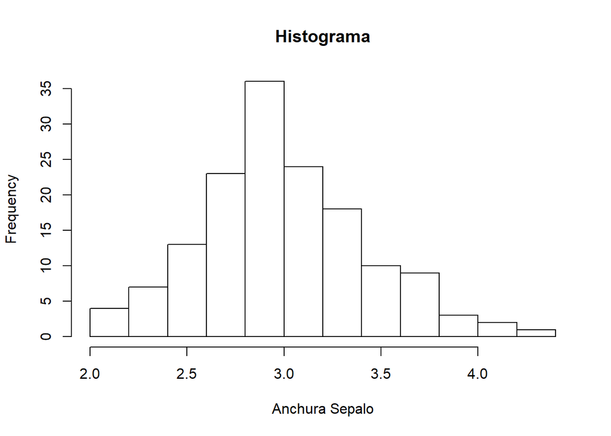

```r
hist <-hist(iris$Sepal.Width, xlab = "Anchura Sepalo",main = "Histograma")
```

```r
data <- iris[,c(2,5)]
```

Ahora para obtener nuestro discriminante lineal usamos la siguiente formula.
$$\delta(x) = log(\pi_k) + \frac{x\mu_k}{\sigma^2}-\frac{1}{2}(\frac{\mu_k}{\sigma})^2$$
Como tenemos tres diferentes especies, $k = 3$ y como no conocemos la media ni la varianza usaremos los siguentes estimadores.

$$\begin{array}{l}
\hat{\pi}_k = \frac{n_k}{n}\\
\hat{\mu}_k = \frac{1}{n_k}\sum_{i:y_i=k}x_i\\
\hat{\sigma}^2 = \sum_{k = 1}^K\frac{n_k-1}{n - K}\hat{\sigma}_k^2
\end{array}$$
donde $\hat{\sigma}_k^2 = \frac{1}{n_k-1}\sum_{i:y_i=k}(x_i-\hat{\mu}_k)^2$, es decir el estimador de varianza casual.

```r
delta <-function(x,i=1){
  log(pis[i]) + (x*medias[i]-(1/2)*medias[i]^2)/var
}
```

Ahora crearemos unos datos para correr la prueba

```r
test<-rnorm(50,mean = 3, sd = .9)
```

Ya que estan creados los datos, hacemos la prueba y obtenemos los siguientes resultados.

```r
nombres <-  c("setosa", "versicolor","virginica")
res <- matrix(rep(0,150),ncol = 3)

for (i in 1:50)
{
  for (j in 1:3)
    {
    res[i,j] = delta(test[i],j)
    }
}
vec_res <- max.col(res)
(respuesta <- data.frame(nombres[vec_res]))
```

```
##    nombres.vec_res.
## 1            setosa
## 2        versicolor
## 3            setosa
## 4        versicolor
## 5         virginica
## 6            setosa
## 7            setosa
## 8            setosa
## 9        versicolor
## 10       versicolor
## 11       versicolor
## 12           setosa
## 13           setosa
## 14           setosa
```

[output cut: 36 more lines]

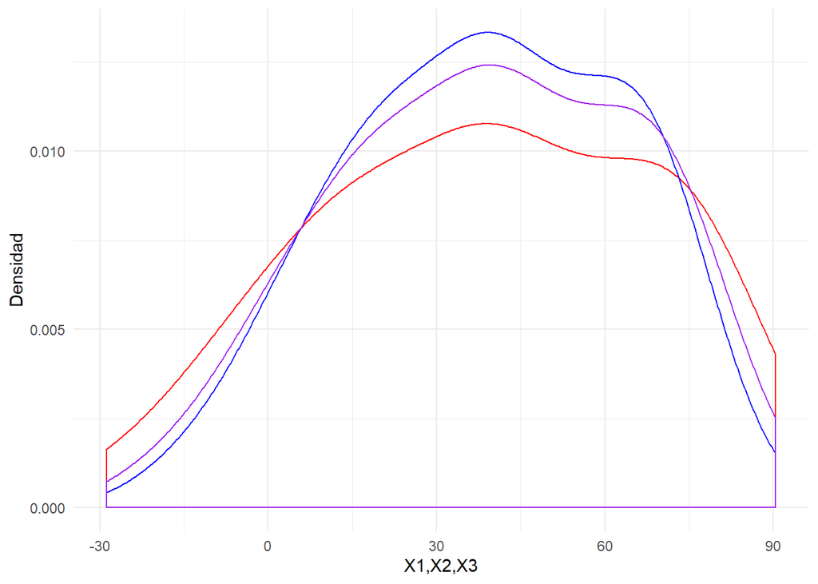

```r
res <- data.frame(res)
(deltas <-ggplot(res) + geom_density(aes(x = X1), color = 'red')+geom_density(aes(x = X2), color = 'blue')+geom_density(aes(x = X3), color = 'purple') + theme_minimal()+ xlab("X1,X2,X3")+ ylab("Densidad") )
```

Donde la grafica roja corresponde a $\delta(x)_1$, la grafica azul corresponde a $\delta(x)_2$ y la morada a$\delta(x)_3$